# Práctica 1: Estadística descriptiva

Estadística - Curso 2023/2024

# Introducción y definición de objetivos

El estudio con los datos obtenidos busca observar cómo ciertas variables como la edad, altura, consumo de agua o alcohol, etc.; influye en la obesidad en una persona.

Para esto se han recogido una serie de datos de 2111 testimonios de México, Perú y Colombia

# Importación de datos y carga de paquetes

```r
library(tidyverse)
library(summarytools)
library(GGally)
library(readxl)
library(knitr)
library(remotes)
ObesityDataSet <- read_csv("//10.97.0.20/Home_VDI$/j.borrego.2021/Desktop/Proyecto/practica0/ObesityDataSet.csv")
```

# Diccionario de datos

- `Gender`: Género biológico de cada persona.
- `Age`: Edad de cada persona (años).
- `Height`: Altura de cada persona (m).
- `Weight`: Peso de cada persona (kg).
- `family_history_with_overweight`: Historial clínico de sobrepeso en familiares (YES/NO).
- `FAVC`: Frecuencia de consumición de alimentos altamente calóricos (YES/NO).
- `NPC`: Número de comidas diarias.
- `CAEC`: Frecuencia de consumo de alimentos entre comidas (Sometimes/ Frequently/Always/no).
- `SCC`: Si se controla la cantidad de calorías consumidas (YES/NO).
- `FAF`: Número de veces que se realizan actividades deportivas por día.
- `CALC`: Consumo de alcohol.
- `FCVC`: Frecuencia de consumo de verduras.
- `SMOKE`: Fumador o no.
- `CALC`: Consumo de alcohol.
- `CH2O`: Consumo de agua diaria.
- `TUE`: Tiempo de uso de dispositivos digitales (h).
- `MTRANS`: Qué tipo de medio de transporte se usa (Public_Transportation/ Automobile/ Walking/ Motorbike/ Bike).
- `NObeyesdad`: Nivel de obesidad actual (Insufficient_Weight / Normal_Weight/ Obesity_Type_I/ Obesity_Type_II/ Obesity_Type_III/ Overweight_Level_I/ Overweight_Level_II)
- `IMC`: Índice de masa corporal Peso(kg)/Altura^2(m)

## Variable transformada, calculada con la altura y el peso para que nos sea de más utilidad

```r
  IMC=(ObesityDataSet$Weight/((ObesityDataSet$Height)^2))
  age= as.integer(ObesityDataSet$Age)
```

Añadimos una variable adicional, el IMC, que es la discretización de la variable NObeyesdad correspondiendo ciertos rangos de IMC a un tipo de obesidad. Por ejemplo: para Obesity_Type_I el IMC va desde 30 a 34,9.

Por otra parte, la edad la convertiremos en un número entero, ya que en este estudio se hizo el cálculo preciso de edades desde el nacimiento hasta el día del estudio.

# Análisis exploratorio de datos

## Datos univariantes

### Número de mujeres y hombres en el estudio

```r
ObesityDataSet |>
  count(Gender)
```

```
## # A tibble: 2 × 2
##   Gender     n
##   <chr>  <int>
## 1 Female  1043
## 2 Male    1068
```

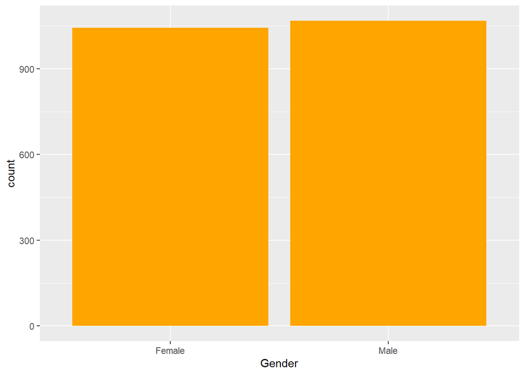

```r
ObesityDataSet |>
  ggplot(aes(Gender)) +
  geom_bar(fill = "orange")
```

Para empezar a hablar de este proyecto estadístico, vamos a hacer un estudio de los testimonios que han rellenado los datos de las variables. La tabla y el código de barras indica que hay un número similar de mujeres y hombres. Concretamente 1043 mujeres y 1068 hombres.

### Estudio de las edades de la muestra y peso

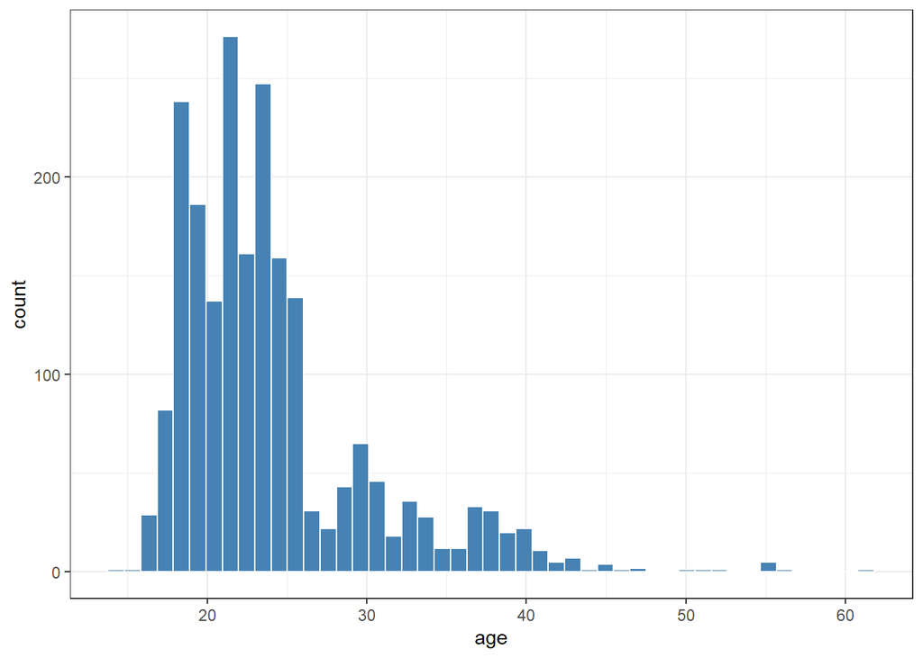

```r
ObesityDataSet |> ggplot(aes(age)) +
  geom_histogram(fill = "steelblue", bins = 47, col = "white") +
  theme_bw()
```

```r
summary(age)
```

```
##    Min. 1st Qu.  Median    Mean 3rd Qu.    Max.
##   14.00   19.00   22.00   23.97   26.00   61.00
```

En cuanto a la edad de los individuos del estudio, observamos que la media es de 24 años y la mediana de 22, aunque la mayoría son jóvenes entre 14 y 26 años también hay personas más mayores hasta los 61 años.

### IMC de las personas

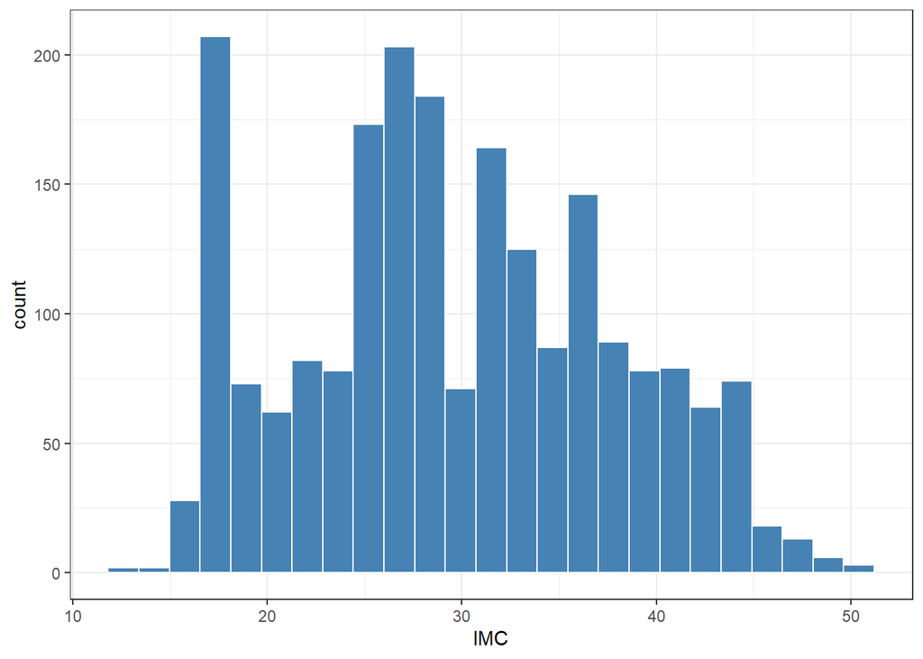

```r
ObesityDataSet |> ggplot(aes(IMC)) +
    geom_histogram(fill = "steelblue", bins = 25, col = "white") +
    theme_bw()
```

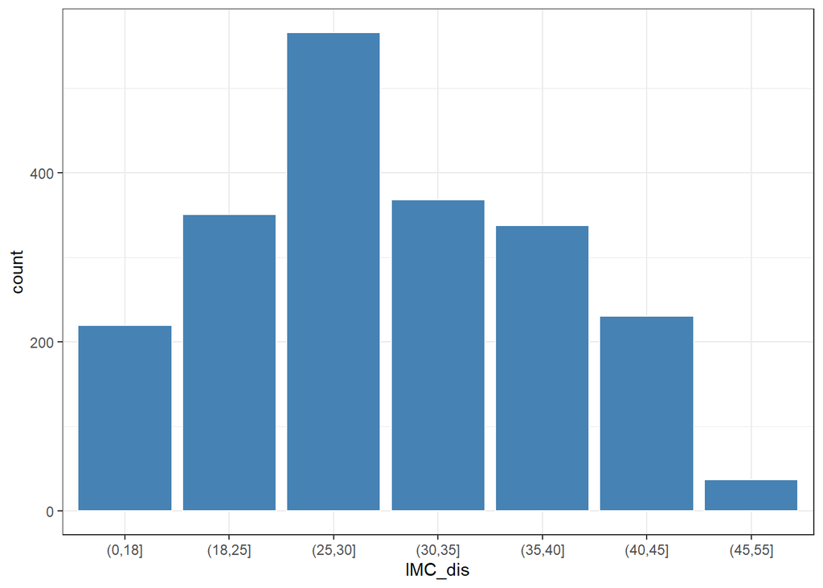

```r
'IMC_dis' <- cut(IMC, breaks = c(0,18,25,30,35,40,45,55), lables= c('0-18.4','18.5-24.9','25-29.9','30-34.9','40-44.9','45-55'))
ObesityDataSet |> ggplot(aes(IMC_dis)) +
    geom_bar(fill = "steelblue", bins = 25, col = "white") +
    theme_bw()
```

```r
descr(IMC)
```

```
## Descriptive Statistics
## IMC
## N: 2111
##
##                         IMC
## ----------------- ---------
##              Mean     29.70
##           Std.Dev      8.01
##               Min     13.00
##                Q1     24.31
##            Median     28.72
##                Q3     36.02
##               Max     50.81
##               MAD      9.07
##               IQR     11.69
##                CV      0.27
##          Skewness      0.15
##       SE.Skewness      0.05
##          Kurtosis     -0.81
##           N.Valid   2111.00
##         Pct.Valid    100.00
```

Los niveles de obesidad corresponden a rangos de IMC, por lo que es más sentido en vez de hacer un histograma, hacer un gráfico de barras por rangos, correspondiendo a un tipo de obesidad. Por lo que de [0,18] corresponde con insuficiencia, de [18,25] con peso normal, de [25,30] con sobrepeso, de [30,35] con preobesidad, de [35,40] con sobrepeso tipo I, de [40,45] con sobrepeso tipo II y de [45,55] corresponde con obesidad tipo III

### Número de personas con historial de personas con obesidad en la familia

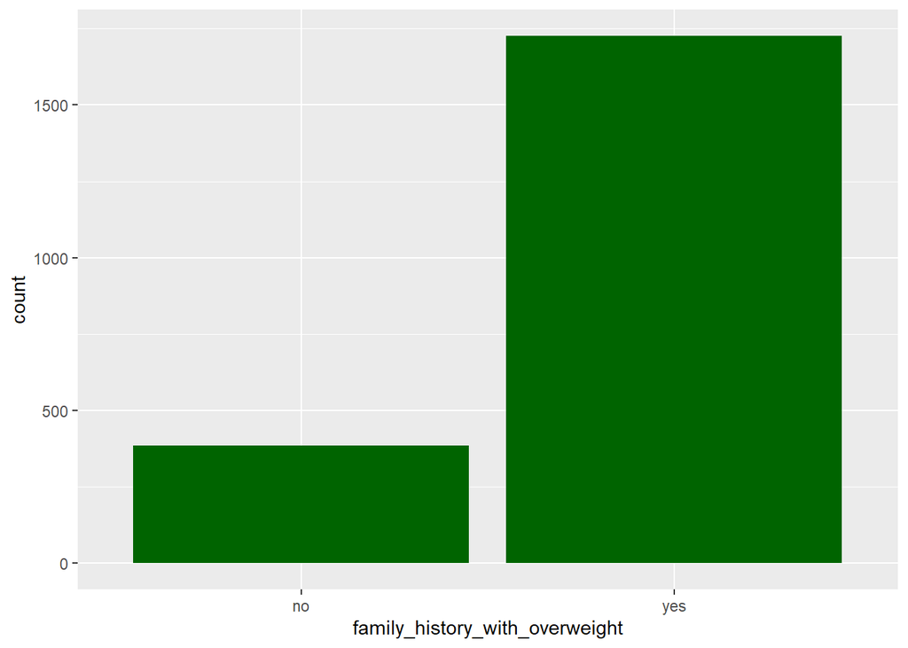

```r
ObesityDataSet |>  ggplot(aes(family_history_with_overweight)) + geom_bar(fill = "darkgreen")
```

Gracias a este gráfico de barras, se puede destacar que desafortunadamente existen una gran mayoría de personas con familiares que han tenido sobrepeso.

### Número de personas que consumen alimentos altamente calóricos

```r
table (ObesityDataSet$FAVC)
```

```
##
##   no  yes
##  245 1866
```

Otro hecho triste es que hay muchos que consideran llevar una dieta basada en comidas altamente calóricas.

### Comidas diarias al día

```r
prop.table(table(as.integer(ObesityDataSet$NCP), ObesityDataSet$CAEC))
```

```
##
##           Always   Frequently           no    Sometimes
##   1 0.0047370914 0.0232117480 0.0137375651 0.1454287068
##   2 0.0000000000 0.0052108006 0.0004737091 0.1293225959
##   3 0.0156324017 0.0724774988 0.0099478920 0.5471340597
##   4 0.0047370914 0.0137375651 0.0000000000 0.0142112743
```

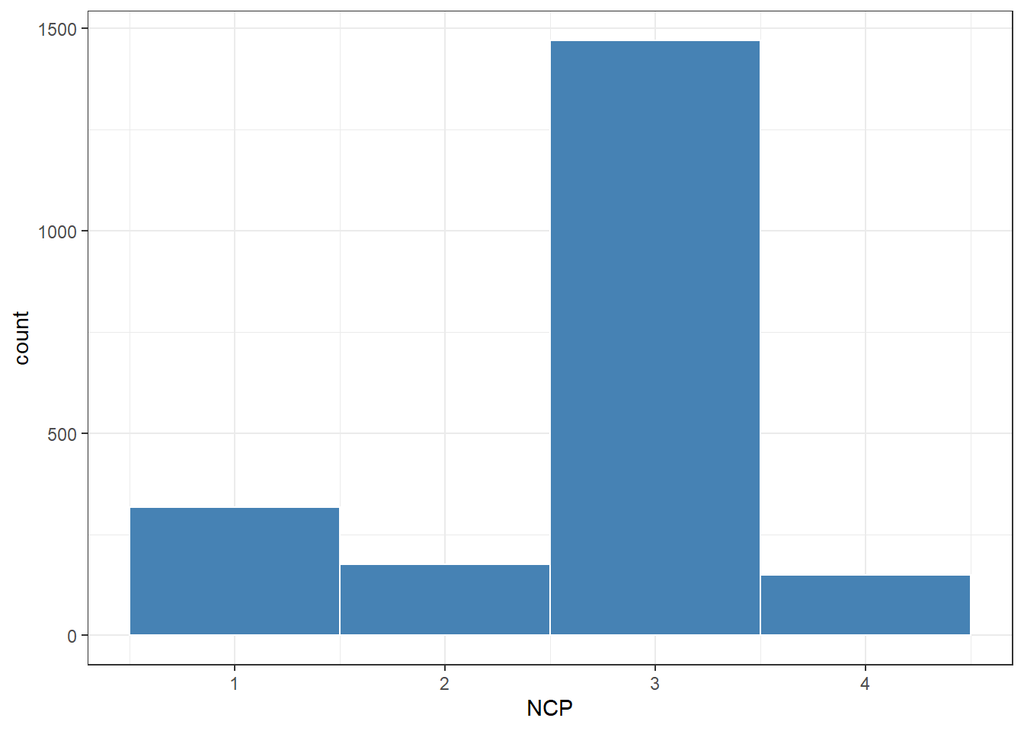

```r
ObesityDataSet |> ggplot(aes(NCP)) +
  geom_histogram(fill = "steelblue", bins = 4, col = "white") +
  theme_bw()
```

Para la tabla, necesitamos hacer la variable NCP entera ya que no es lógico que alguien coma una vez y media. Suponemos que es posible que en la medición de datos, se hizo una media del consumo diario, el cual, no viene expresado en ninguna parte del estudio.

Pese a que la mayor parte de la gente realiza 3 comidas diarias tenemos una gran parte de personas que consume 1 o 2 comidas diarias, incluso personas que llegan a hacer 4 comidas diarias.

### Frecuencias medio de trasporte

```r
knitr::kable(prop.table(table(ObesityDataSet$MTRANS)))
```

| Var1 | Freq |
| --- | --- |
| Automobile | 0.2164851 |
| Bike | 0.0033160 |
| Motorbike | 0.0052108 |
| Public_Transportation | 0.7484604 |
| Walking | 0.0265277 |

La tabla de frecuencias del método de transporte muestra como los que se desplazan en vehículos como el transporte público o el automóvil son una clara mayoría frente a los que se desplazan en bicicleta o caminando.

### Frecuencias niveles de obesidad

```r
knitr::kable(prop.table(table(ObesityDataSet$NObeyesdad)))
```

| Var1 | Freq |
| --- | --- |
| Insufficient_Weight | 0.1288489 |
| Normal_Weight | 0.1359545 |
| Obesity_Type_I | 0.1662719 |
| Obesity_Type_II | 0.1406916 |
| Obesity_Type_III | 0.1534818 |
| Overweight_Level_I | 0.1373757 |
| Overweight_Level_II | 0.1373757 |

Contrariamente a los métodos de transporte, en los tipos de obesidad vemos que la repartición es más uniforme, es decir, no hay casos aislados.

### Covarianza y correlación

```r
knitr::kable(cov(ObesityDataSet |> select(Age, Weight, Height, FCVC, NCP, CH2O, FAF, TUE)) |> round(3))
```

|  | Age | Weight | Height | FCVC | NCP | CH2O | FAF | TUE |
| --- | --- | --- | --- | --- | --- | --- | --- | --- |
| Age | 40.271 | 33.667 | -0.015 | 0.055 | -0.217 | -0.176 | -0.782 | -1.147 |
| Weight | 33.667 | 685.977 | 1.132 | 3.022 | 2.190 | 3.220 | -1.146 | -1.141 |
| Height | -0.015 | 1.132 | 0.009 | -0.002 | 0.018 | 0.012 | 0.023 | 0.003 |
| FCVC | 0.055 | 3.022 | -0.002 | 0.285 | 0.018 | 0.022 | 0.009 | -0.033 |
| NCP | -0.217 | 2.190 | 0.018 | 0.018 | 0.605 | 0.027 | 0.086 | 0.017 |
| CH2O | -0.176 | 3.220 | 0.012 | 0.022 | 0.027 | 0.376 | 0.087 | 0.004 |
| FAF | -0.782 | -1.146 | 0.023 | 0.009 | 0.086 | 0.087 | 0.724 | 0.030 |
| TUE | -1.147 | -1.141 | 0.003 | -0.033 | 0.017 | 0.004 | 0.030 | 0.371 |

De esta tabla no podemos sacar nada relevante visto que los valores de covarianza son muy dispares

```r
knitr::kable(cor(ObesityDataSet |> select(Age, Weight, Height, FCVC, NCP, CH2O, FAF, TUE)) |> round(3))
```

|  | Age | Weight | Height | FCVC | NCP | CH2O | FAF | TUE |
| --- | --- | --- | --- | --- | --- | --- | --- | --- |
| Age | 1.000 | 0.203 | -0.026 | 0.016 | -0.044 | -0.045 | -0.145 | -0.297 |
| Weight | 0.203 | 1.000 | 0.463 | 0.216 | 0.107 | 0.201 | -0.051 | -0.072 |
| Height | -0.026 | 0.463 | 1.000 | -0.038 | 0.244 | 0.213 | 0.295 | 0.052 |
| FCVC | 0.016 | 0.216 | -0.038 | 1.000 | 0.042 | 0.068 | 0.020 | -0.101 |
| NCP | -0.044 | 0.107 | 0.244 | 0.042 | 1.000 | 0.057 | 0.130 | 0.036 |
| CH2O | -0.045 | 0.201 | 0.213 | 0.068 | 0.057 | 1.000 | 0.167 | 0.012 |
| FAF | -0.145 | -0.051 | 0.295 | 0.020 | 0.130 | 0.167 | 1.000 | 0.059 |
| TUE | -0.297 | -0.072 | 0.052 | -0.101 | 0.036 | 0.012 | 0.059 | 1.000 |

En esta tabla vemos las correlaciones entre nuestras variables numéricas y destacamos la correlación entre la altura y el peso que nos da el valor más alto (0.463). Decidimos que no vale la pena analizar el resto de las variables puesto que su correlación es muy baja.

## Tablas bivariantes

### Número de personas con alimentos calóricos y control de calorías

```r
addmargins(table(ObesityDataSet$FAVC, ObesityDataSet$SCC))
```

```
##
##         no  yes  Sum
##   no   207   38  245
##   yes 1808   58 1866
##   Sum 2015   96 2111
```

Viendo el número de personas que cumplen la condición de consumir alimentos calóricos y controlarlos vemos que la mayoría consumen alimentos altamente calóricos y no controlan este último, lo que nos muestra el descuido de la dieta que tiene la muestra.

### Número de personas con alimentos calóricos y control de calorías en porcentaje

```r
summarytools::ctable(ObesityDataSet$FAVC, ObesityDataSet$SCC)
```

```
## Cross-Tabulation, Row Proportions
## FAVC * SCC
## Data Frame: ObesityDataSet
##
## ------- ----- -------------- ------------ ---------------
##           SCC             no          yes           Total
##    FAVC
##      no          207 (84.5%)   38 (15.5%)    245 (100.0%)
##     yes         1808 (96.9%)   58 ( 3.1%)   1866 (100.0%)
##   Total         2015 (95.5%)   96 ( 4.5%)   2111 (100.0%)
## ------- ----- -------------- ------------ ---------------
```

Misma gráfica que la anterior, pero en porcentaje

### Número de personas con historial clínico y consumidores de alimentos altamente calóricos en porcentaje

```r
summarytools::ctable(ObesityDataSet$family_history_with_overweight,ObesityDataSet$FAVC)
```

```
## Cross-Tabulation, Row Proportions
## family_history_with_overweight * FAVC
## Data Frame: ObesityDataSet
##
## -------------------------------- ------ ------------- -------------- ---------------
##                                    FAVC            no            yes           Total
##   family_history_with_overweight
##                               no           99 (25.7%)    286 (74.3%)    385 (100.0%)
##                              yes          146 ( 8.5%)   1580 (91.5%)   1726 (100.0%)
##                            Total          245 (11.6%)   1866 (88.4%)   2111 (100.0%)
## -------------------------------- ------ ------------- -------------- ---------------
```

Esta tabla compara la existencia de personas con sobrepeso en el historial familiar y el consumo de alimentos calóricos. La gran mayoría de personas con parientes con sobrepeso tienen un consumo elevado de alimentos calóricos lo que nos lleva a pensar que la obesidad tiene relación con el consumo de cierto tipo de alimentos.

## Gráficas bivariantes

### Gráfica de cajas tipo de transporte e IMC

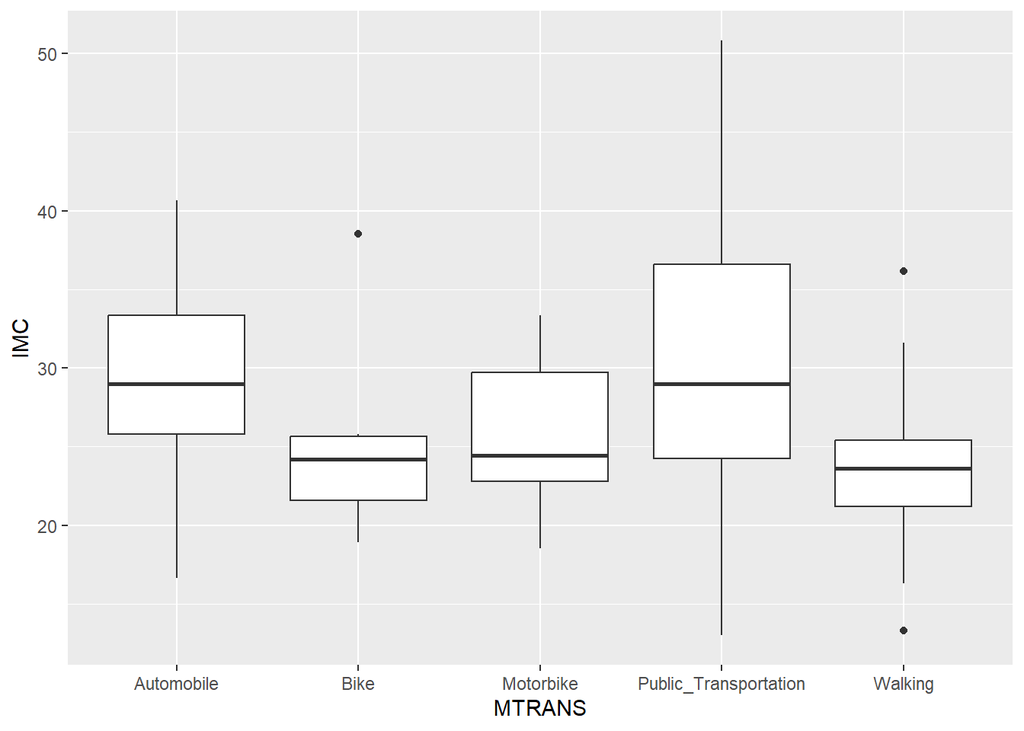

```r
ObesityDataSet |> ggplot(aes(y = IMC , x = MTRANS)) + geom_boxplot()
```

Este gráfico de cajas compara el IMC y el tipo de transporte utilizados. Vemos que los que se desplazan en bicicleta o en motocicleta tienen una mediana equiparada.

Los que caminan, tienen una mediana más cercana a IMC más bajos lo que indica que al moverse, ejercitan el cuerpo haciendo que su IMC sea menor (salvo excepciones que podemos suponer que intentará bajar de peso al igual que sucede con el transporte de bicicleta).

Los métodos de transporte, ya sea público como en vehículo particular, su mediana es mayor indicando que la probabilidad de sobrepeso es mayor.

### Gráfica de cajas alimentarse entre comidas e IMC

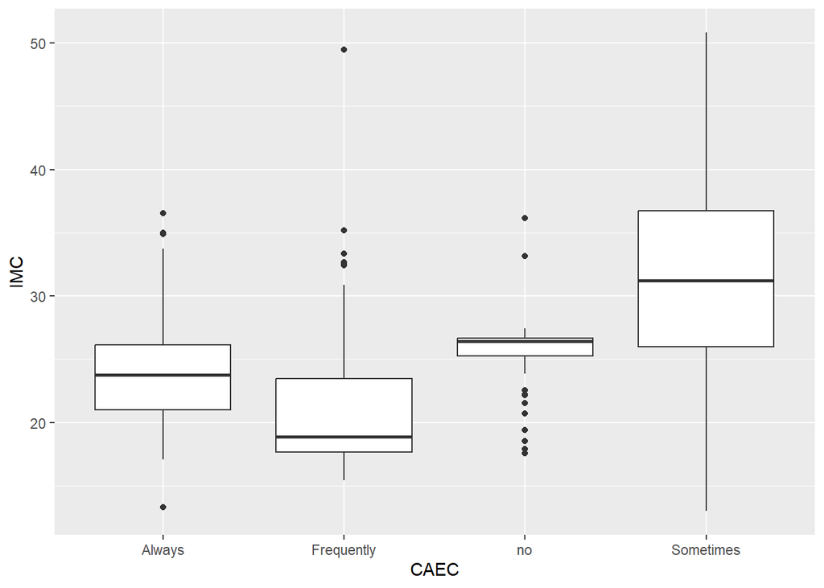

```r
ObesityDataSet |>  ggplot(aes(y = IMC , x = CAEC)) +  geom_boxplot()
```

Si comparamos la frecuencia con la que se consumen alimentos entre comidas y el IMC vemos que no tienen relación, ya que los que no lo consumen tienen un IMC mayor que los que suelen pasar lo que no debería ser así.

### Gráfica de cajas comidas calóricas e IMC

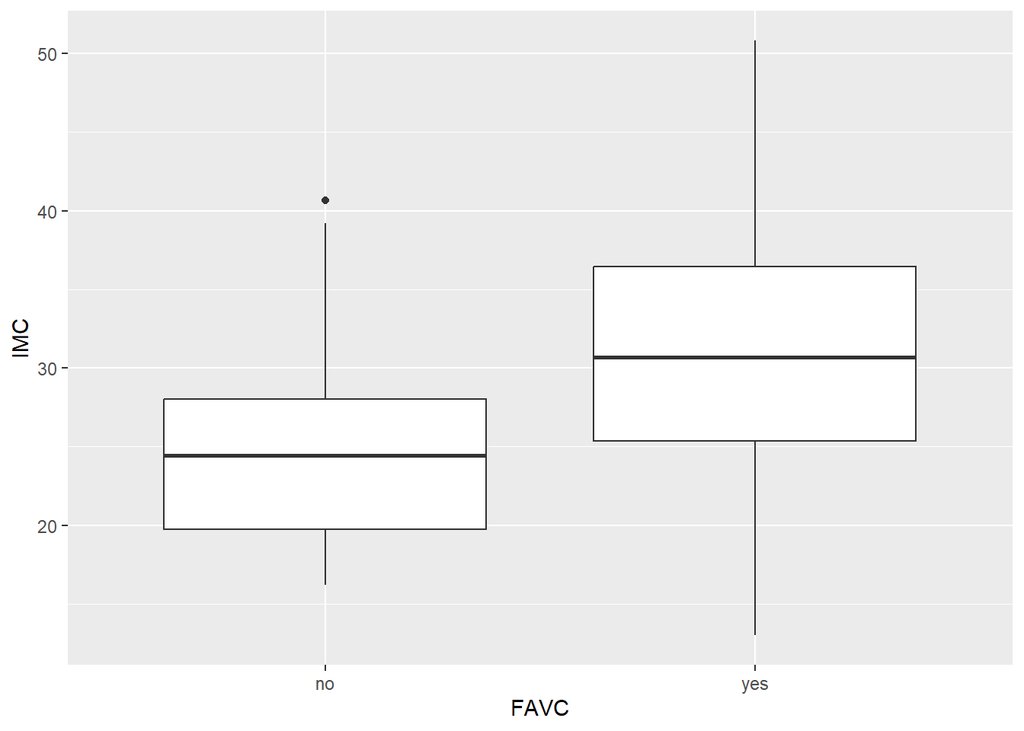

```r
ObesityDataSet |>  ggplot(aes(y = IMC , x = FAVC)) + geom_boxplot()
```

Vemos que hay una relación entre el consumo de alimentos calóricos y el IMC ya que los que se abstienen de consumir dichos alimentos presentan una mediana mucho menor que los que sí la consumen. Aunque sigue habiendo casos extremos en los que esta relación no se cumpla, la relación se cumple para nuestra muestra.

### Gráfica de cajas historial familiar y IMC

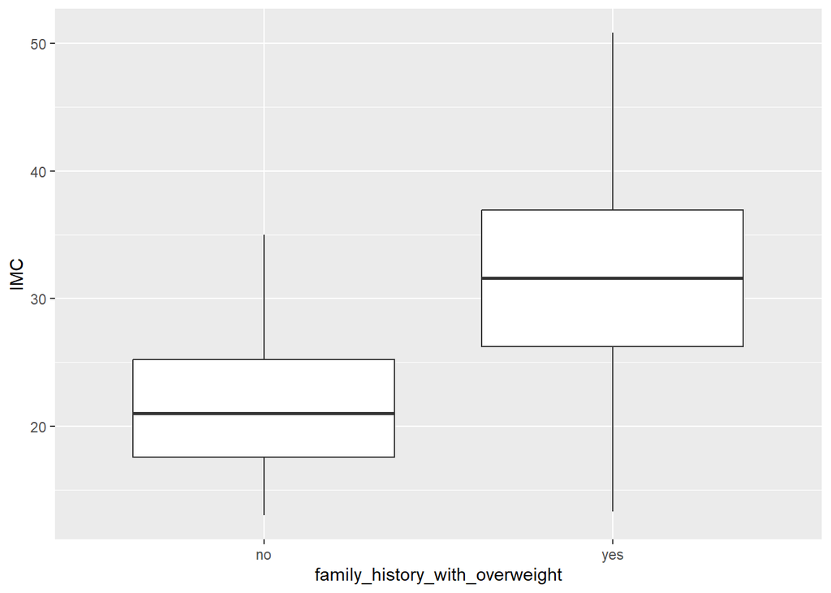

```r
ObesityDataSet |>  ggplot(aes(x = family_history_with_overweight , y = IMC)) +  geom_boxplot()
```

En este gráfico, se concluye que la presencia de un familiar con sobrepeso en la familia puede afectar al IMC por lo que supondremos que se trata de un factor genético que afecta a la obesidad.

### Gráfica de cajas historial familiar y IMC en el subconjunto de comidas altamente calóricas

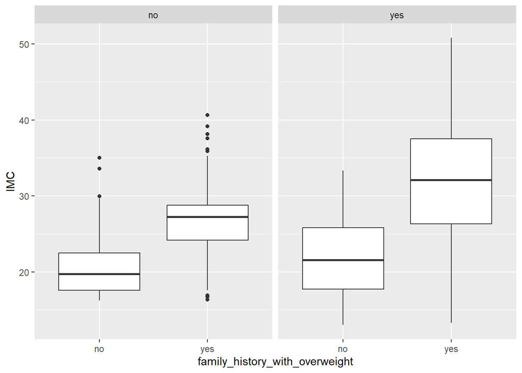

```r
ObesityDataSet |>  ggplot(aes(y = IMC , x = family_history_with_overweight)) +  geom_boxplot()+ facet_wrap("FAVC")
```

Con este gráfico sacamos que la presencia de familiares con sobrepeso y el consumo de alimentos altamente calóricos afecta directamente al incremento del IMC.

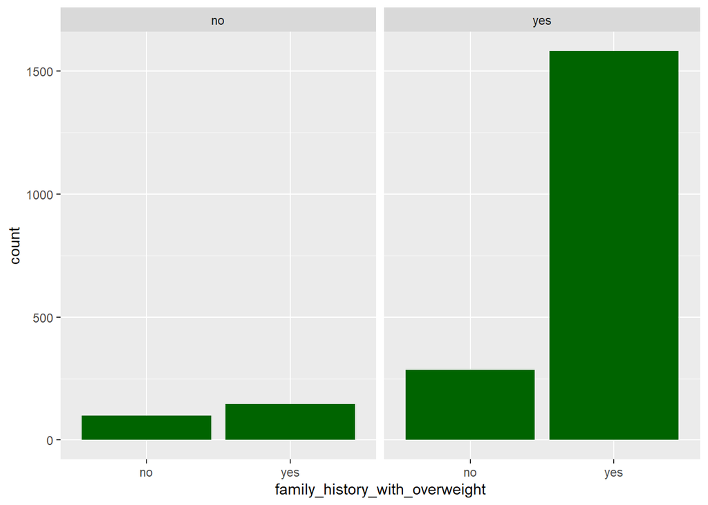

```r
ObesityDataSet |>  ggplot(aes(family_history_with_overweight)) + geom_bar(fill = "darkgreen") + facet_wrap("FAVC")
```

Con este gráfico de barras vemos que la gran mayoría de personas que tienen familiares con sobrepeso consumen frecuentemente alimentos altamente calóricos debido a, como dijimos antes, una alimentación que ha podido ser inculcada.

### Gráfica de cajas del IMC y control de calorías

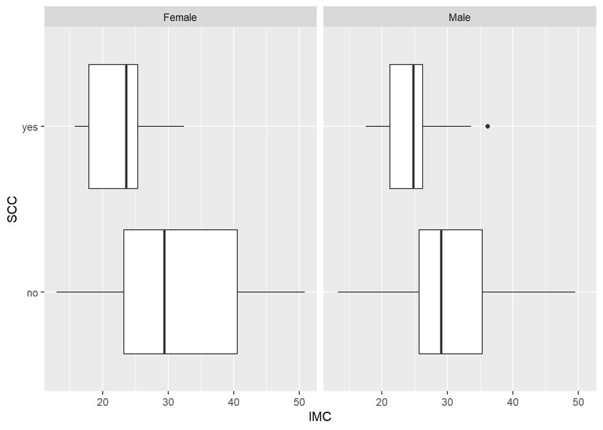

```r
ObesityDataSet |>   ggplot(aes(x = IMC, y = SCC)) +  geom_boxplot() +  facet_wrap("Gender")
```

Esta gráfica que ha sido dividida por géneros, no se puede observar mucha diferencia entre mujeres y hombres con el control de calorías. Sin embargo, se puede observar que le control de las calorías que se consumen tiende a reducir el IMC bastante por lo que una dieta bien controlada es una forma efectiva para reducir el sobrepeso

### Gráfica de puntos de altura e IMC

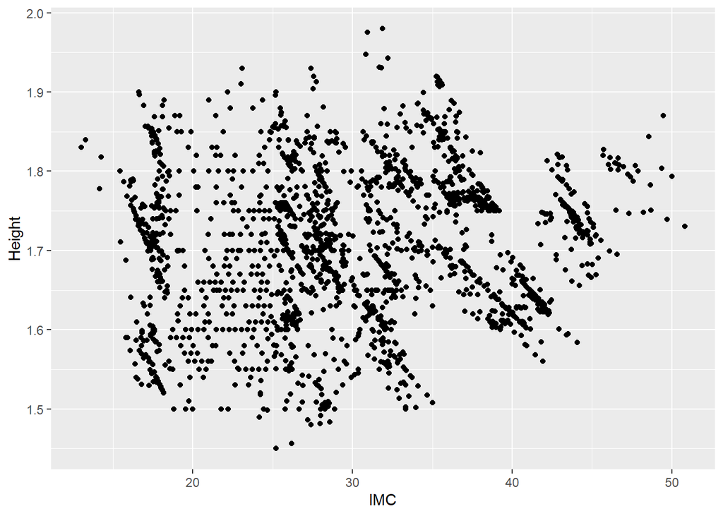

```r
ObesityDataSet |>  ggplot(aes(x = IMC, y = Height)) +  geom_point()
```

### Gráficas con regresiones lineales

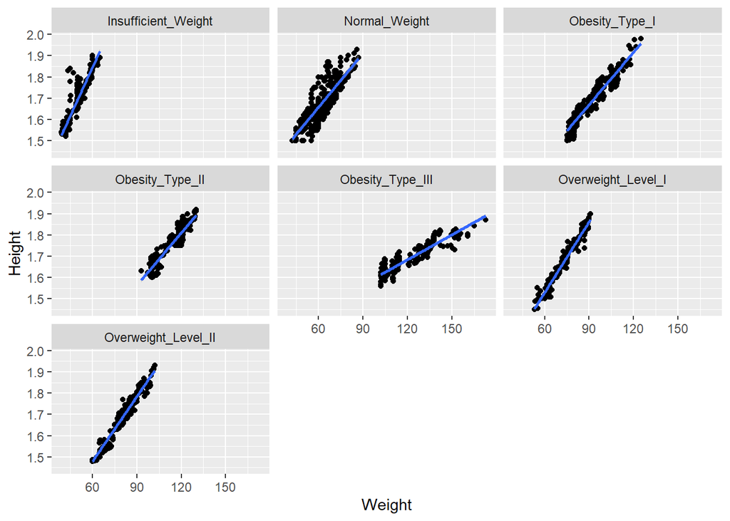

```r
ObesityDataSet |>
  ggplot(aes(x = Weight, y = Height)) +
  facet_wrap("NObeyesdad") +
  geom_point() +
  geom_smooth(method = "lm")
```

#### Correlación de altura y peso en personas del tipo “Insufficient weight”

```r
ObesityDataSet_Ins <- ObesityDataSet %>% filter(NObeyesdad=='Insufficient_Weight')

cor(ObesityDataSet_Ins$Weight , ObesityDataSet_Ins$Height)
```

```
## [1] 0.917854
```

#### Regresión de altura y peso en personas del tipo “Insufficient weight”

```r
modelo<-lm(ObesityDataSet_Ins$Weight ~ ObesityDataSet_Ins$Height)
summary(modelo)
```

```
##
## Call:
## lm(formula = ObesityDataSet_Ins$Weight ~ ObesityDataSet_Ins$Height)
##
## Residuals:
##      Min       1Q   Median       3Q      Max
## -14.0617  -0.9561   0.3587   1.4737   4.6576
##
## Coefficients:
##                           Estimate Std. Error t value Pr(>|t|)
## (Intercept)                -43.685      2.467   -17.7   <2e-16 ***
## ObesityDataSet_Ins$Height   55.343      1.456    38.0   <2e-16 ***
## ---
## Signif. codes:  0 '***' 0.001 '**' 0.01 '*' 0.05 '.' 0.1 ' ' 1
##
## Residual standard error: 2.39 on 270 degrees of freedom
## Multiple R-squared:  0.8425, Adjusted R-squared:  0.8419
## F-statistic:  1444 on 1 and 270 DF,  p-value: < 2.2e-16
```

La recta de regresión lineal tiene la forma: (peso) = (altura)55,343 –43,685. Donde la coeficiente de determinación es 0,8419

#### Correlación de altura y peso en personas del tipo “Normal weight”

```r
ObesityDataSet_Nor <- ObesityDataSet %>% filter(NObeyesdad=='Normal_Weight')

cor(ObesityDataSet_Nor$Weight , ObesityDataSet_Nor$Height)
```

```
## [1] 0.8296194
```

#### Regresión de altura y peso en personas del tipo “Normal weight”

```r
modelo<-lm(ObesityDataSet_Nor$Weight ~ ObesityDataSet_Nor$Height)
summary(modelo)
```

```
##
## Call:
## lm(formula = ObesityDataSet_Nor$Weight ~ ObesityDataSet_Nor$Height)
##
## Residuals:
##      Min       1Q   Median       3Q      Max
## -12.2242  -3.6575   0.2234   4.6584   8.6964
##
## Coefficients:
##                           Estimate Std. Error t value Pr(>|t|)
## (Intercept)                -74.634      5.462  -13.66   <2e-16 ***
## ObesityDataSet_Nor$Height   81.588      3.252   25.09   <2e-16 ***
## ---
## Signif. codes:  0 '***' 0.001 '**' 0.01 '*' 0.05 '.' 0.1 ' ' 1
##
## Residual standard error: 5.199 on 285 degrees of freedom
## Multiple R-squared:  0.6883, Adjusted R-squared:  0.6872
## F-statistic: 629.2 on 1 and 285 DF,  p-value: < 2.2e-16
```

La recta de regresión lineal tiene la forma: (peso) = (altura)81,588 –74,634. Donde la coeficiente de determinación es 0,6872

#### Correlación de altura y peso en personas del tipo “Obesity TypeI”

```r
ObesityDataSet_ObI <- ObesityDataSet %>% filter(NObeyesdad=='Obesity_Type_I')

cor(ObesityDataSet_ObI$Weight , ObesityDataSet_ObI$Height)
```

```
## [1] 0.9577455
```

#### Regresión de altura y peso en personas del tipo “Obesity TypeI”

```r
modelo<-lm(ObesityDataSet_ObI$Weight ~ ObesityDataSet_ObI$Height)
summary(modelo)
```

```
##
## Call:
## lm(formula = ObesityDataSet_ObI$Weight ~ ObesityDataSet_ObI$Height)
##
## Residuals:
##     Min      1Q  Median      3Q     Max
## -6.6875 -2.5739 -0.2102  2.1488  8.6548
##
## Coefficients:
##                           Estimate Std. Error t value Pr(>|t|)
## (Intercept)                -96.461      3.049  -31.64   <2e-16 ***
## ObesityDataSet_ObI$Height  111.779      1.797   62.21   <2e-16 ***
## ---
## Signif. codes:  0 '***' 0.001 '**' 0.01 '*' 0.05 '.' 0.1 ' ' 1
##
## Residual standard error: 3.308 on 349 degrees of freedom
## Multiple R-squared:  0.9173, Adjusted R-squared:  0.917
## F-statistic:  3870 on 1 and 349 DF,  p-value: < 2.2e-16
```

#### Correlación de altura y peso en personas del tipo “Obesity TypeII”

```r
ObesityDataSet_ObII <- ObesityDataSet %>% filter(NObeyesdad=='Obesity_Type_II')

cor(ObesityDataSet_ObII$Weight , ObesityDataSet_ObII$Height)
```

```
## [1] 0.9077753
```

#### Regresión de altura y peso en personas del tipo “Obesity TypeII”

```r
modelo<-lm(ObesityDataSet_ObII$Weight ~ ObesityDataSet_ObII$Height)
summary(modelo)
```

```
##
## Call:
## lm(formula = ObesityDataSet_ObII$Weight ~ ObesityDataSet_ObII$Height)
##
## Residuals:
##     Min      1Q  Median      3Q     Max
## -8.1024 -2.0592 -0.1502  2.5939  6.8778
##
## Coefficients:
##                            Estimate Std. Error t value Pr(>|t|)
## (Intercept)                 -62.166      4.778  -13.01   <2e-16 ***
## ObesityDataSet_ObII$Height  100.165      2.695   37.17   <2e-16 ***
## ---
## Signif. codes:  0 '***' 0.001 '**' 0.01 '*' 0.05 '.' 0.1 ' ' 1
##
## Residual standard error: 3.372 on 295 degrees of freedom
## Multiple R-squared:  0.8241, Adjusted R-squared:  0.8235
## F-statistic:  1382 on 1 and 295 DF,  p-value: < 2.2e-16
```

La recta de regresión lineal tiene la forma: (peso) = (altura)100,165 –62,166. Donde la coeficiente de determinación es 0,8235

#### Correlación de altura y peso en personas del tipo “Obesity TypeIII”

```r
ObesityDataSet_ObIII <- ObesityDataSet %>% filter(NObeyesdad=='Obesity_Type_III')

cor(ObesityDataSet_ObIII$Weight , ObesityDataSet_ObIII$Height)
```

```
## [1] 0.9276969
```

#### Regresión de altura y peso en personas del tipo “Obesity TypeIII”

```r
modelo<-lm(ObesityDataSet_ObIII$Weight ~ ObesityDataSet_ObIII$Height)
summary(modelo)
```

```
##
## Call:
## lm(formula = ObesityDataSet_ObIII$Weight ~ ObesityDataSet_ObIII$Height)
##
## Residuals:
##      Min       1Q   Median       3Q      Max
## -16.0916  -3.1223   0.3332   3.1721  21.7580
##
## Coefficients:
##                             Estimate Std. Error t value Pr(>|t|)
## (Intercept)                 -251.650      8.362  -30.09   <2e-16 ***
## ObesityDataSet_ObIII$Height  220.787      4.952   44.59   <2e-16 ***
## ---
## Signif. codes:  0 '***' 0.001 '**' 0.01 '*' 0.05 '.' 0.1 ' ' 1
##
## Residual standard error: 5.808 on 322 degrees of freedom
## Multiple R-squared:  0.8606, Adjusted R-squared:  0.8602
## F-statistic:  1988 on 1 and 322 DF,  p-value: < 2.2e-16
```

La recta de regresión lineal tiene la forma: (peso) = (altura)220,787 –251,650. Donde la coeficiente de determinación es 0,8602

#### Correlación de altura y peso en personas del tipo “Overweight Level I”

```r
ObesityDataSet_OvI <- ObesityDataSet %>% filter(NObeyesdad=='Overweight_Level_I')

cor(ObesityDataSet_OvI$Weight , ObesityDataSet_OvI$Height)
```

```
## [1] 0.9773795
```

#### Regresión de altura y peso en personas del tipo “Overweight Level I”

```r
modelo<-lm(ObesityDataSet_OvI$Weight ~ ObesityDataSet_OvI$Height)
summary(modelo)
```

```
##
## Call:
## lm(formula = ObesityDataSet_OvI$Weight ~ ObesityDataSet_OvI$Height)
##
## Residuals:
##     Min      1Q  Median      3Q     Max
## -7.5580 -1.1410  0.0719  1.1297  8.3141
##
## Coefficients:
##                           Estimate Std. Error t value Pr(>|t|)
## (Intercept)                -71.298      1.859  -38.35   <2e-16 ***
## ObesityDataSet_OvI$Height   86.243      1.100   78.43   <2e-16 ***
## ---
## Signif. codes:  0 '***' 0.001 '**' 0.01 '*' 0.05 '.' 0.1 ' ' 1
##
## Residual standard error: 1.795 on 288 degrees of freedom
## Multiple R-squared:  0.9553, Adjusted R-squared:  0.9551
## F-statistic:  6151 on 1 and 288 DF,  p-value: < 2.2e-16
```

La recta de regresión lineal tiene la forma: (peso) = (altura)86,243 -71,298. Donde la coeficiente de determinación es 0,9551

#### Correlación de altura y peso en personas del tipo “Overweight Level II”

```r
ObesityDataSet_OvII <- ObesityDataSet %>% filter(NObeyesdad=='Overweight_Level_II')

cor(ObesityDataSet_OvII$Weight , ObesityDataSet_OvII$Height)
```

```
## [1] 0.9603451
```

#### Regresión de altura y peso en personas del tipo “Overweight Level II”

```r
modelo<-lm(ObesityDataSet_OvII$Weight ~ ObesityDataSet_OvII$Height)
summary(modelo)
```

```
##
## Call:
## lm(formula = ObesityDataSet_OvII$Weight ~ ObesityDataSet_OvII$Height)
##
## Residuals:
##     Min      1Q  Median      3Q     Max
## -7.5393 -1.6689 -0.1349  1.7240  6.1808
##
## Coefficients:
##                            Estimate Std. Error t value Pr(>|t|)
## (Intercept)                 -72.512      2.648  -27.38   <2e-16 ***
## ObesityDataSet_OvII$Height   90.740      1.552   58.45   <2e-16 ***
## ---
## Signif. codes:  0 '***' 0.001 '**' 0.01 '*' 0.05 '.' 0.1 ' ' 1
##
## Residual standard error: 2.36 on 288 degrees of freedom
## Multiple R-squared:  0.9223, Adjusted R-squared:  0.922
## F-statistic:  3417 on 1 and 288 DF,  p-value: < 2.2e-16
```

# Conclusiones

[output not shown]